# Lab 7: Functions + Fish

Author

Trycia Vong

The goal of this lab is learn more about exploring missing data and writing modular code.

```r
library(tidyverse)
library(knitr)
library(purrr)
library(patchwork)

fish <- read.csv("BlackfootFish.csv")
```

## The Data

This lab’s data concerns mark-recapture data on four species of trout from the Blackfoot River outside of Helena, Montana. These four species are **rainbow trout (RBT)**, **westslope cutthroat trout (WCT)**, **bull trout**, and **brown trout**.

Mark-recapture is a common method used by ecologists to estimate a population’s size when it is impossible to conduct a census (count every animal). This method works by *tagging* animals with a tracking device so that scientists can track their movement and presence.

## Data Exploration

The measurements of each captured fish were taken by a biologist on a raft in the river. The lack of a laboratory setting opens the door to the possibility of measurement errors.

**1. Let’s look for missing values in the dataset. Output ONE table that answers BOTH of the following questions:**

- **How many observations have missing values?**
- **What variable(s) have missing values present?**

```r
# Code for Q1. https://chatgpt.com/share/6828cb0c-5f80-8009-98fd-7824c4774d70

fish_na <- fish |>
  filter(if_any(.cols = trip : species,
                .fns = ~ is.na(.x)))

column_w_na <- fish |>
  select(trip:species) |>
  summarise(across(everything(), ~ any(is.na(.)))) |>
  pivot_longer(everything(), names_to = "column", values_to = "has_na") |>
  filter(has_na) |>
  pull(column)

# Show number of such rows and which columns have NAs
tibble(
  rows_with_na = nrow(fish_na),
  columns_with_na = paste(column_w_na, collapse = ", ")
) |> kable()
```

| rows_with_na | columns_with_na |
| --- | --- |
| 1796 | weight |

**2. Create ONE thoughtful visualization that explores the frequency of missing values across the different years, sections, and trips.**

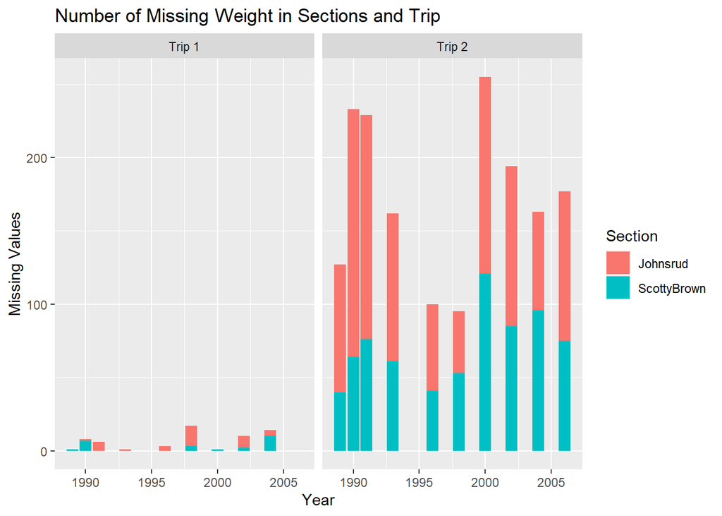

```r
# Code for Q2. https://stackoverflow.com/questions/48860158/changing-ggplot2facet-wrap-title-from-the-default

ggplot(data = fish_na, aes(x = year, fill = section)) +
  geom_bar() +
  facet_wrap(vars(trip), labeller = labeller(trip = c("1" = "Trip 1",
                                                      "2" = "Trip 2"))) +
  labs(title = "Number of Missing Weight in Sections and Trip", x = "Year", y = "Missing Values", fill = "Section")
```

## Rescaling the Data

If I wanted to rescale every quantitative variable in my dataset so that they only have values between 0 and 1, I could use this formula:

$$y_{scaled} = \frac{y_i - min\{y_1, y_2,..., y_n\}}{max\{y_1, y_2,..., y_n\}
- min\{y_1, y_2,..., y_n\}}$$

I might write the following `R` code to carry out the rescaling procedure for the `length` and `weight` columns of the `BlackfootFish` data:

```r
fish <- fish |>
  mutate(length = (length - min(length, na.rm = TRUE)) /
           (max(length, na.rm = TRUE) - min(length, na.rm = TRUE)),
         weight = (weight - min(weight, na.rm = TRUE)) /
           (max(weight, na.rm = TRUE) - min(length, na.rm = TRUE)))
```

This process of duplicating an action multiple times can make it difficult to understand the intent of the process. *Additionally, it can make it very difficult to spot mistakes.*

**3. What is the mistake I made in the above rescaling code?**

When finding weight, the denominator is using length instead of weight, a common error from copying and pasting.

**4. Transform the repeated process above into a `rescale_01()` function. Your function should…**

- **… take a single vector as input.**
- **… return the rescaled vector.**

```r
# Code for Q4 and Q5.

rescale_01 <- function(input) {
  stopifnot(is.numeric(input) | length(input) >= 1)
  min_max_input <- range(input, na.rm = TRUE)
  input <- (input - min_max_input[1]) / (min_max_input[2] - min_max_input[1])
  return(input)
}
```

**5. Let’s incorporate some input validation into your function. Modify your previous code so that the function stops if …**

- **… the input vector is not numeric.**
- **… the length of the input vector is not greater than 1.**

## Test Your Function

**6. Run the code below to test your function. Verify that the maximum of your rescaled vector is 1 and the minimum is 0!**

```r
x <- c(1:25, NA)

rescaled <- rescale_01(x)
min(rescaled, na.rm = TRUE)
```

```
[1] 0
```

```r
max(rescaled, na.rm = TRUE)
```

```
[1] 1
```

Next, let’s test the function on the `length` column of the `BlackfootFish` data.

**7. The code below makes a histogram of the original values of `length`. Add a plot of the rescaled values of `length`. Output your plots side-by-side, so the reader can confirm the only aspect that has changed is the scale.**

**Tip**

1. Set the y-axis limits for both plots to go from 0 to 4000 to allow for direct comparison across plots.
2. Pay attention to `binwidth`! Adjust it so that the plots are comparable (they may not look exactly the same).
3. Look for a Quarto code-chunk option to put the plots side-by-side.

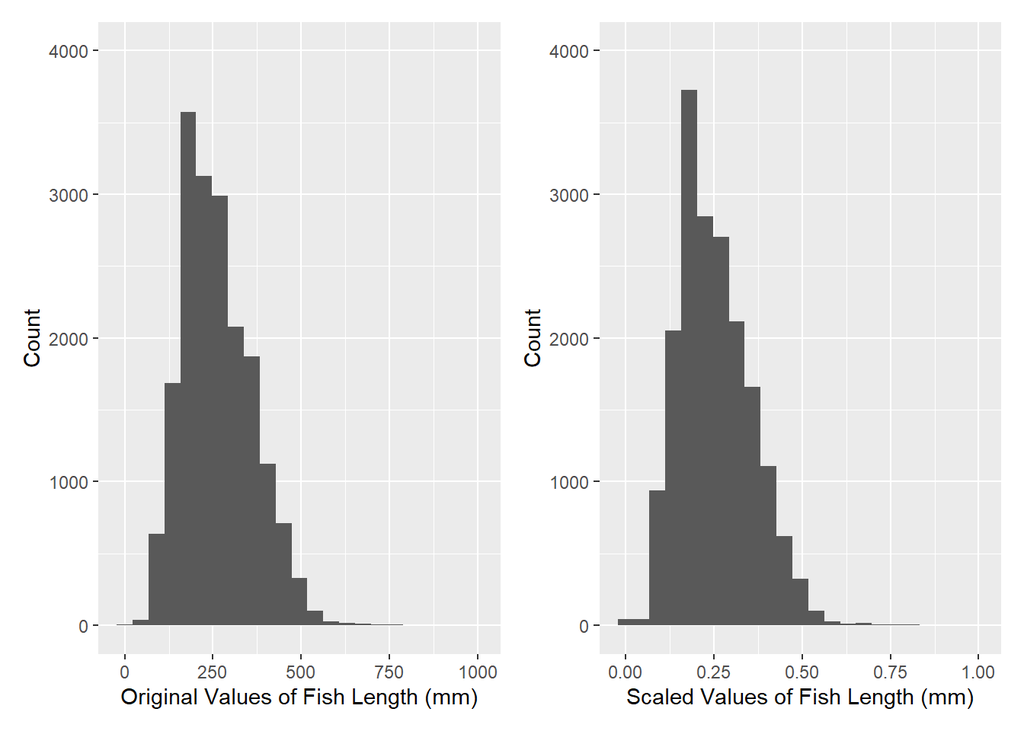

```r
# Code for Q7 plot. #https://chatgpt.com/share/68267683-97f4-8009-a13f-3bc72b63c4c7

fish1 <- fish |>
  ggplot(aes(x = length)) +
  geom_histogram(binwidth = 45) +
  labs(x = "Original Values of Fish Length (mm)", y = "Count") +
  scale_y_continuous(limits = c(0,4000))

fish2 <- fish |>
  mutate(length_scaled = rescale_01(length)) |>
  ggplot(aes(x = length_scaled)) +
  geom_histogram(binwidth = 0.045, na.rm = TRUE) +
  labs(x = "Scaled Values of Fish Length (mm)", y = "Count") +
  scale_y_continuous(limits = c(0,4000))

fish1 + fish2
```

## Use Variables within a Dataset

Suppose you would like for your `rescale()` function to perform operations on a **variable within a dataset**. Ideally, your function would take in a dataframe and a variable name as inputs and return a dataframe where the variable has been rescaled.

**8. Create a `rescale_column()` function that accepts two arguments: (1) a dataframe and (2) the name(s) of the variable(s) to be rescaled. The body of the function should call the original `rescale_01()` function you wrote previously. Your solution MUST use one of the `rlang` options from class.**

```r
# Code for Q8.

rescale_column <- function(df, names) {
  df <- df |>
    mutate(across(.cols = {{names}},
                  .fns = ~ rescale_01(.x)))
  return(df)
}
```

**9. Use your `rescale_column()` function to rescale *both* the `length` and `weight` columns.**

```r
# Code for Q9.

# original values
fish |>
 select(length:weight) |>
 head() |>
  kable()
```

| length | weight |
| --- | --- |
| 288 | 175 |
| 288 | 190 |
| 285 | 245 |
| 322 | 275 |
| 312 | 300 |
| 363 | 380 |

```r
# rescaled values
rescale_column(fish, length : weight) |>
  select(length : weight) |>
  head() |>
  kable()
```

| length | weight |
| --- | --- |
| 0.2804124 | 0.0374171 |
| 0.2804124 | 0.0406243 |
| 0.2773196 | 0.0523840 |
| 0.3154639 | 0.0587984 |
| 0.3051546 | 0.0641437 |
| 0.3577320 | 0.0812487 |

## Condition Index

A frequently used measurement for fish health is a condition index ([Wikipedia](https://en.wikipedia.org/wiki/Condition_index_in_fish)). The following equation can be used to calculate the approximate condition index of a fish:

$$\text{condition index} = \frac{weight}{length^3} \times 100$$

**10. When calculating the condition index, fish length must be in centimeters and fish weight must be in grams. The weight data for the Blackfoot River fish were collected in grams, but the length data were collected in millimeters. Transform the length column to the correct units.**

```r
# Code for Q10.

fish <- fish |>
  mutate(length = length / 10)
```

**11. Collecting data of this sort can be very messy! Write a function that will replace unlikely `length` and `weight` measurements with `NA`. Your function should accept at least three inputs:**

- **a vector of measurements,**
- **the minimum reasonable value,**
- **the maximum reasonable value.**

```r
# Code for Q11.https://stackoverflow.com/questions/71928189/conditionally-replace-values-with-na-in-r

replace_unreasonable <- function(vec, min, max) {
  vec[(vec < min) | (vec > max)] <- NA
  return(vec)
}
```

**12. After consulting the [Montana Record Table](https://fwp.mt.gov/fish/anglingData/records) for the 4 species of trout included in these data, I have conjectured that it is unlikely to have measurements for fish below 5 cm and above 80 cm in length or below 10 g and above 4,000 g in weight. Use your function to modify the `length` and `weight` columns of the `fish` dataset based on my cutoffs.**

```r
# Code for Q12.

fish <- fish |>
  mutate(length = replace_unreasonable(length, 5, 80)) |>
  mutate(weight = replace_unreasonable(weight, 10, 4000))
```

**13. Write a function to calculate the condition index of a fish, given inputs of weight and length. Show that it works on your modified `fish` dataset**

```r
# Code for Q13.

condition_index_calc <- function(weight, length) {
  return((weight / (length ^ 3)) * 100)
}

fish <- fish |>
  mutate(condition_index = round(condition_index_calc(fish$weight, fish$length), 2))

head(fish) |> kable()
```

| trip | mark | length | weight | year | section | species | condition_index |
| --- | --- | --- | --- | --- | --- | --- | --- |
| 1 | 0 | 28.8 | 175 | 1989 | Johnsrud | RBT | 0.73 |
| 1 | 0 | 28.8 | 190 | 1989 | Johnsrud | RBT | 0.80 |
| 1 | 0 | 28.5 | 245 | 1989 | Johnsrud | RBT | 1.06 |
| 1 | 0 | 32.2 | 275 | 1989 | Johnsrud | RBT | 0.82 |
| 1 | 0 | 31.2 | 300 | 1989 | Johnsrud | RBT | 0.99 |
| 1 | 0 | 36.3 | 380 | 1989 | Johnsrud | RBT | 0.79 |